# RNN Assignment

## Recurrent Neural Networks vs Transformers for Time Series Prediction

### STUDENT INFORMATION

**BITS** : 2025AE05649  
**Name** : Gadde Jaya krishna Swamy  
**Email** : 2025ae05649@wilp.bits-pilani.ac.in  
**Date** : 03-05-2026

## Assignment Overview

This assignment implements and compares two approaches for time series forecasting:

1. **GRU** using Keras/TensorFlow with 2 stacked layers
2. **Transformer** encoder using Keras layers with custom positional encoding

**Framework**: Keras/TensorFlow  
**Dataset**: Apple (AAPL) Stock Prices from Yahoo Finance  
**Train/Test Split**: 90/10 (Temporal - NO shuffling)  
**Metrics**: MAE, RMSE, MAPE, R²

```python
#!pip install -q numpy pandas matplotlib seaborn scikit-learn tensorflow yfinance
```

```python
# Import Required Libraries
import numpy as np
import pandas as pd
import matplotlib.pyplot as plt
import seaborn as sns
import time
import warnings
warnings.filterwarnings('ignore')

# Data processing
from sklearn.preprocessing import MinMaxScaler
from sklearn.metrics import mean_absolute_error, mean_squared_error, r2_score

# Deep Learning
import tensorflow as tf
from tensorflow import keras
from tensorflow.keras.models import Sequential, Model
from tensorflow.keras.layers import (
    GRU, Dense, Dropout, Input, LayerNormalization,
    MultiHeadAttention, GlobalAveragePooling1D, Add, Reshape, Layer
)
from tensorflow.keras.optimizers import Adam
from tensorflow.keras.callbacks import EarlyStopping

# Yahoo Finance for stock data
try:
    import yfinance as yf
except ImportError:
    import subprocess
    subprocess.check_call(['pip', 'install', 'yfinance'])
    import yfinance as yf

# Set random seeds for reproducibility
np.random.seed(42)
tf.random.set_seed(42)

print("✓ All libraries imported successfully")
```

```
✓ All libraries imported successfully
```

## PART 1: DATASET LOADING AND EXPLORATION

```python
# Download Apple stock data - daily closing prices (>1000 time steps)
ticker = "AAPL"
data_raw = yf.download(ticker, start="2018-01-01", end="2024-12-31", progress=False)
data_raw = data_raw[['Close']].dropna()
data_raw.columns = ['Close']

print(f"Downloaded {len(data_raw)} daily records for {ticker}")
print(f"Date range: {data_raw.index[0].strftime('%Y-%m-%d')} to {data_raw.index[-1].strftime('%Y-%m-%d')}")
print(f"\nFirst 5 rows:")
print(data_raw.head())
print(f"\nBasic Statistics:")
print(data_raw.describe())

# REQUIRED: Metadata fields
dataset_name = "Apple Inc. (AAPL) Stock Prices"
dataset_source = "Yahoo Finance (yfinance library)"
n_samples = len(data_raw)
n_features = 1
sequence_length = 30
prediction_horizon = 1
problem_type = "time_series_forecasting"

# Primary metric selection
primary_metric = "RMSE"
metric_justification = """RMSE is chosen as the primary metric because it penalizes larger prediction errors
more heavily than MAE, which is critical in stock price forecasting where large
deviations can have significant financial implications."""

print("\n" + "="*60)
print("DATASET INFORMATION")
print("="*60)
print(f"Dataset: {dataset_name}")
print(f"Source: {dataset_source}")
print(f"Total Samples: {n_samples}")
print(f"Number of Features: {n_features}")
print(f"Sequence Length: {sequence_length}")
print(f"Prediction Horizon: {prediction_horizon}")
print(f"Primary Metric: {primary_metric}")
print(f"Metric Justification: {metric_justification}")
```

```
Downloaded 1760 daily records for AAPL
Date range: 2018-01-02 to 2024-12-30

First 5 rows:
                Close
Date
2018-01-02  40.304173
2018-01-03  40.297150
2018-01-04  40.484333
2018-01-05  40.945251
2018-01-08  40.793190

Basic Statistics:
             Close
count  1760.000000
mean    121.664108
std      59.001785
min      33.768082
25%      54.026789
50%     131.293945
75%     168.494431
max     257.612701

============================================================
DATASET INFORMATION
============================================================
Dataset: Apple Inc. (AAPL) Stock Prices
Source: Yahoo Finance (yfinance library)
Total Samples: 1760
Number of Features: 1
Sequence Length: 30
Prediction Horizon: 1
Primary Metric: RMSE
Metric Justification: RMSE is chosen as the primary metric because it penalizes larger prediction errors
more heavily than MAE, which is critical in stock price forecasting where large
deviations can have significant financial implications.
```

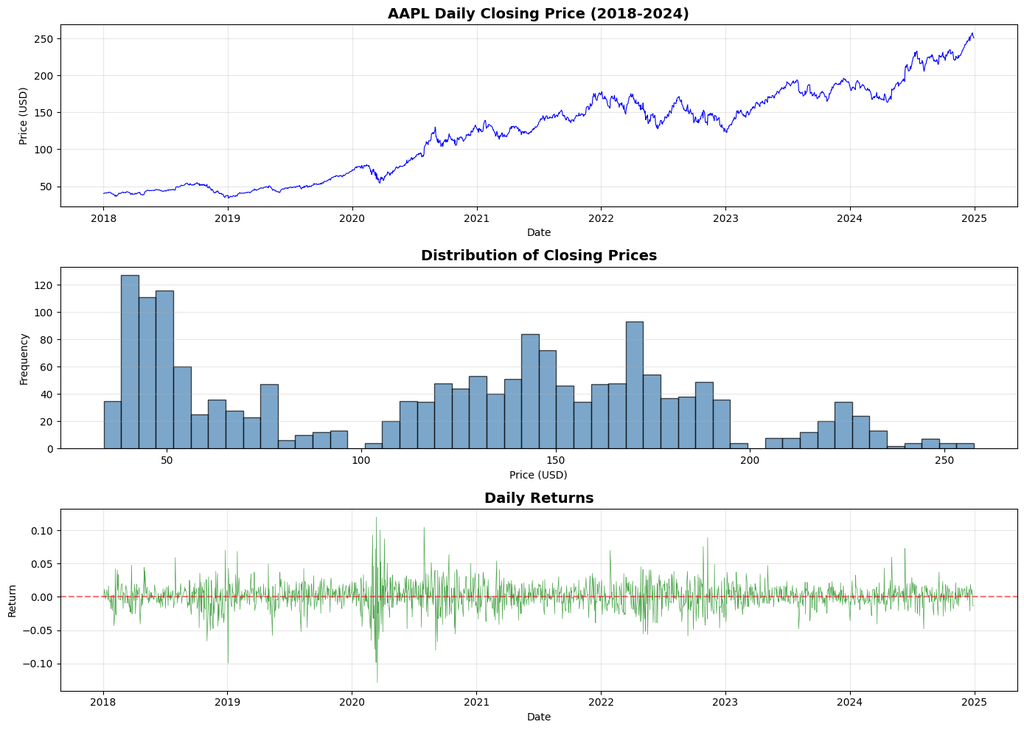

```
Daily Returns - Mean: 0.001225, Std: 0.019247
```

```python
# Time Series Exploration
fig, axes = plt.subplots(3, 1, figsize=(14, 10))

axes[0].plot(data_raw.index, data_raw['Close'], color='blue', linewidth=0.8)
axes[0].set_title(f'{ticker} Daily Closing Price (2018-2024)', fontsize=14, fontweight='bold')
axes[0].set_xlabel('Date')
axes[0].set_ylabel('Price (USD)')
axes[0].grid(True, alpha=0.3)

axes[1].hist(data_raw['Close'], bins=50, color='steelblue', edgecolor='black', alpha=0.7)
axes[1].set_title('Distribution of Closing Prices', fontsize=14, fontweight='bold')
axes[1].set_xlabel('Price (USD)')
axes[1].set_ylabel('Frequency')
axes[1].grid(True, alpha=0.3, axis='y')

returns = data_raw['Close'].pct_change().dropna()
axes[2].plot(returns.index, returns, color='green', linewidth=0.5, alpha=0.7)
axes[2].set_title('Daily Returns', fontsize=14, fontweight='bold')
axes[2].set_xlabel('Date')
axes[2].set_ylabel('Return')
axes[2].axhline(y=0, color='red', linestyle='--', alpha=0.5)
axes[2].grid(True, alpha=0.3)

plt.tight_layout()
plt.show()

print(f"Daily Returns - Mean: {returns.mean():.6f}, Std: {returns.std():.6f}")
```

```
Scaled data shape: (1760,)
Scaled data range: [0.0000, 1.0000]

Sequences created:
X shape: (1730, 30) (samples, sequence_length, features)
y shape: (1730, 1) (samples, prediction_horizon)

============================================================
TRAIN/TEST SPLIT (TEMPORAL - NO SHUFFLING)
============================================================
Train/Test Split: 90/10
Training Samples: 1557
Test Samples: 173
Total Sequences: 1730
```

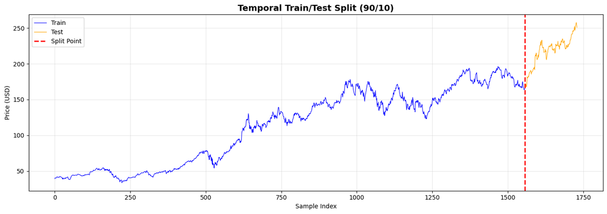

```python
# Data Preprocessing Functions

def preprocess_timeseries(data):
    """Normalize time series data using MinMaxScaler"""
    scaler = MinMaxScaler(feature_range=(0, 1))
    scaled_data = scaler.fit_transform(data.values.reshape(-1, 1))
    return scaled_data.flatten(), scaler

def create_sequences(data, seq_length, pred_horizon=1):
    """Create sliding window sequences for time series"""
    X, y = [], []
    for i in range(len(data) - seq_length - pred_horizon + 1):
        X.append(data[i:i + seq_length])
        y.append(data[i + seq_length:i + seq_length + pred_horizon])
    return np.array(X), np.array(y)

def calculate_mape(y_true, y_pred):
    """Calculate Mean Absolute Percentage Error"""
    mask = y_true != 0
    return np.mean(np.abs((y_true[mask] - y_pred[mask]) / y_true[mask])) * 100

# Preprocess data
scaled_data, scaler = preprocess_timeseries(data_raw['Close'])
print(f"Scaled data shape: {scaled_data.shape}")
print(f"Scaled data range: [{scaled_data.min():.4f}, {scaled_data.max():.4f}]")

# Create sequences
X, y = create_sequences(scaled_data, sequence_length, prediction_horizon)
print(f"\nSequences created:")
print(f"X shape: {X.shape} (samples, sequence_length, features)")
print(f"y shape: {y.shape} (samples, prediction_horizon)")

# REQUIRED: Temporal train/test split (NO SHUFFLING)
split_ratio = 0.9
split_idx = int(len(X) * split_ratio)

X_train, X_test = X[:split_idx], X[split_idx:]
y_train, y_test = y[:split_idx], y[split_idx:]

train_test_ratio = "90/10"
train_samples = len(X_train)
test_samples = len(X_test)

print(f"\n" + "="*60)
print("TRAIN/TEST SPLIT (TEMPORAL - NO SHUFFLING)")
print("="*60)
print(f"Train/Test Split: {train_test_ratio}")
print(f"Training Samples: {train_samples}")
print(f"Test Samples: {test_samples}")
print(f"Total Sequences: {len(X)}")

# Visualize train/test split
fig, ax = plt.subplots(figsize=(14, 5))
train_indices = range(split_idx)
test_indices = range(split_idx, split_idx + test_samples)
ax.plot(train_indices, scaler.inverse_transform(y_train), label='Train', color='blue', linewidth=0.8)
ax.plot(test_indices, scaler.inverse_transform(y_test), label='Test', color='orange', linewidth=0.8)
ax.axvline(x=split_idx, color='red', linestyle='--', linewidth=2, label='Split Point')
ax.set_title('Temporal Train/Test Split (90/10)', fontsize=14, fontweight='bold')
ax.set_xlabel('Sample Index')
ax.set_ylabel('Price (USD)')
ax.legend(fontsize=10)
ax.grid(True, alpha=0.3)
plt.tight_layout()
plt.show()
```

## PART 2: GRU IMPLEMENTATION

**Architecture**: GRU with 2 stacked layers (64 and 32 units)  
**Regularization**: Dropout for regularization  
**Optimizer**: Adam optimizer, MSE loss  
**Callback**: EarlyStopping to prevent overfitting

```python
# GRU Architecture Design - 2 Stacked Layers
def build_rnn_model(input_shape, hidden_units=64, output_size=1):
    """Build GRU model with 2 stacked layers"""
    model = Sequential([
        GRU(hidden_units, activation='relu', return_sequences=True, input_shape=input_shape),
        Dropout(0.2),
        GRU(32, activation='relu', return_sequences=False),  # 2nd stacked layer
        Dropout(0.2),
        Dense(16, activation='relu'),
        Dense(output_size)
    ])
    model.compile(optimizer=Adam(learning_rate=0.001), loss='mse', metrics=['mae'])
    return model

# Create GRU model
rnn_model = build_rnn_model(
    input_shape=(sequence_length, n_features),
    hidden_units=64,
    output_size=prediction_horizon
)

print("\n" + "="*60)
print("GRU MODEL ARCHITECTURE")
print("="*60)
rnn_model.summary()
rnn_total_params = rnn_model.count_params()
print(f"\nTotal GRU Model Parameters: {rnn_total_params:,}")
```

```
============================================================
GRU MODEL ARCHITECTURE
============================================================
```

```
Model: "sequential"
```

```
┏━━━━━━━━━━━━━━━━━━━━━━━━━━━━━━━━━┳━━━━━━━━━━━━━━━━━━━━━━━━┳━━━━━━━━━━━━━━━┓
┃ Layer (type)                    ┃ Output Shape           ┃       Param # ┃
┡━━━━━━━━━━━━━━━━━━━━━━━━━━━━━━━━━╇━━━━━━━━━━━━━━━━━━━━━━━━╇━━━━━━━━━━━━━━━┩
│ gru (GRU)                       │ (None, 30, 64)         │        12,864 │
├─────────────────────────────────┼────────────────────────┼───────────────┤
│ dropout (Dropout)               │ (None, 30, 64)         │             0 │
├─────────────────────────────────┼────────────────────────┼───────────────┤
│ gru_1 (GRU)                     │ (None, 32)             │         9,408 │
├─────────────────────────────────┼────────────────────────┼───────────────┤
│ dropout_1 (Dropout)             │ (None, 32)             │             0 │
├─────────────────────────────────┼────────────────────────┼───────────────┤
│ dense (Dense)                   │ (None, 16)             │           528 │
├─────────────────────────────────┼────────────────────────┼───────────────┤
│ dense_1 (Dense)                 │ (None, 1)              │            17 │
└─────────────────────────────────┴────────────────────────┴───────────────┘
```

```
 Total params: 22,817 (89.13 KB)
```

```
 Trainable params: 22,817 (89.13 KB)
```

```
 Non-trainable params: 0 (0.00 B)
```

```
Total GRU Model Parameters: 22,817
```

```python
# Train GRU Model
print("\n" + "="*60)
print("GRU MODEL TRAINING")
print("="*60)

rnn_start_time = time.time()

rnn_history = rnn_model.fit(
    X_train, y_train,
    epochs=50,
    batch_size=32,
    validation_split=0.1,
    callbacks=[EarlyStopping(monitor='val_loss', patience=10, restore_best_weights=True)],
    verbose=0
)

rnn_training_time = time.time() - rnn_start_time

# Track initial and final loss
rnn_initial_loss = rnn_history.history['loss'][0]
rnn_final_loss = rnn_history.history['loss'][-1]

print(f"\nTraining completed in {rnn_training_time:.2f} seconds")
print(f"Total Epochs: {len(rnn_history.history['loss'])}")
print(f"Initial Loss: {rnn_initial_loss:.6f}")
print(f"Final Loss: {rnn_final_loss:.6f}")
rnn_loss_reduction = ((rnn_initial_loss - rnn_final_loss) / rnn_initial_loss) * 100
print(f"Loss Reduction: {rnn_loss_reduction:.2f}% ✓")
```

```
============================================================
GRU MODEL TRAINING
============================================================

Training completed in 18.11 seconds
Total Epochs: 13
Initial Loss: 0.048928
Final Loss: 0.001264
Loss Reduction: 97.42% ✓
```

```
============================================================
GRU MODEL EVALUATION
============================================================

RNN (GRU) Model Performance Metrics:
MAE   (Mean Absolute Error):           6.2540
RMSE  (Root Mean Squared Error):      7.3917
MAPE  (Mean Absolute Percentage Error): 2.8739%
R² Score (Coefficient of Determination): 0.8608
```

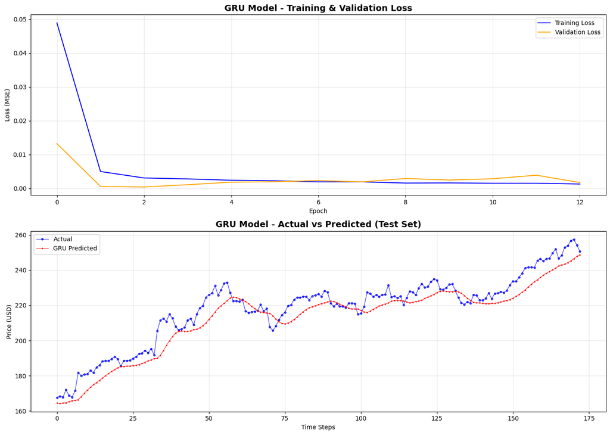

```python
# Evaluate GRU Model
print("\n" + "="*60)
print("GRU MODEL EVALUATION")
print("="*60)

# Make predictions on test set
rnn_predictions_scaled = rnn_model.predict(X_test, verbose=0)

# Inverse transform to original scale
rnn_predictions = scaler.inverse_transform(rnn_predictions_scaled)
y_test_actual = scaler.inverse_transform(y_test)

# Calculate all 4 metrics on original scale
rnn_mae = mean_absolute_error(y_test_actual, rnn_predictions)
rnn_rmse = np.sqrt(mean_squared_error(y_test_actual, rnn_predictions))
rnn_mape = calculate_mape(y_test_actual, rnn_predictions)
rnn_r2 = r2_score(y_test_actual, rnn_predictions)

print("\nRNN (GRU) Model Performance Metrics:")
print(f"MAE   (Mean Absolute Error):           {rnn_mae:.4f}")
print(f"RMSE  (Root Mean Squared Error):      {rnn_rmse:.4f}")
print(f"MAPE  (Mean Absolute Percentage Error): {rnn_mape:.4f}%")
print(f"R² Score (Coefficient of Determination): {rnn_r2:.4f}")

# Visualize GRU Results
fig, axes = plt.subplots(2, 1, figsize=(14, 10))

axes[0].plot(rnn_history.history['loss'], label='Training Loss', color='blue', linewidth=1.5)
axes[0].plot(rnn_history.history['val_loss'], label='Validation Loss', color='orange', linewidth=1.5)
axes[0].set_title('GRU Model - Training & Validation Loss', fontsize=14, fontweight='bold')
axes[0].set_xlabel('Epoch')
axes[0].set_ylabel('Loss (MSE)')
axes[0].legend(fontsize=10)
axes[0].grid(True, alpha=0.3)

axes[1].plot(y_test_actual.flatten(), label='Actual', color='blue', linewidth=1, marker='o', markersize=3, alpha=0.7)
axes[1].plot(rnn_predictions.flatten(), label='GRU Predicted', color='red', linewidth=1, marker='s', markersize=2, alpha=0.7)
axes[1].set_title('GRU Model - Actual vs Predicted (Test Set)', fontsize=14, fontweight='bold')
axes[1].set_xlabel('Time Steps')
axes[1].set_ylabel('Price (USD)')
axes[1].legend(fontsize=10)
axes[1].grid(True, alpha=0.3)

plt.tight_layout()
plt.show()
```

## PART 3: TRANSFORMER IMPLEMENTATION

**Custom Positional Encoding**: Sinusoidal **Multi-Head Attention**: Keras MultiHeadAttention with 4 heads  
**Architecture**: 2 Transformer encoder layers  
**Residual Connections**: Yes  
**Layer Normalization**: Yes

```python
# Positional Encoding Implementation (MANDATORY)
class PositionalEncoding(Layer):
    """Custom Sinusoidal Positional Encoding Layer"""
    def __init__(self, seq_length, d_model, **kwargs):
        super(PositionalEncoding, self).__init__(**kwargs)
        self.seq_length = seq_length
        self.d_model = d_model

    def call(self, x):
        """Generate positional encoding using sinusoidal functions"""
        pos = np.arange(self.seq_length)[:, np.newaxis]
        dim = np.arange(self.d_model)[np.newaxis, :]

        # PE(pos, 2i) = sin(pos / 10000^(2i/d_model))
        # PE(pos, 2i+1) = cos(pos / 10000^(2i/d_model))
        angle_rates = 1 / np.power(10000, (2 * (dim // 2)) / np.float32(self.d_model))
        angle_rads = pos * angle_rates

        # Apply sin to even indices; cos to odd indices
        angle_rads[:, 0::2] = np.sin(angle_rads[:, 0::2])
        angle_rads[:, 1::2] = np.cos(angle_rads[:, 1::2])

        pos_encoding = angle_rads[np.newaxis, ...]
        return x + tf.cast(pos_encoding, dtype=x.dtype)

    def get_config(self):
        config = super().get_config()
        config.update({'seq_length': self.seq_length, 'd_model': self.d_model})
        return config

# Verify positional encoding
print("\n" + "="*60)
print("POSITIONAL ENCODING VERIFICATION")
print("="*60)

d_model = 64
pe_test = PositionalEncoding(sequence_length, d_model)
test_input = tf.zeros((1, sequence_length, d_model))
pe_output = pe_test(test_input)

print(f"Positional Encoding verified:")
print(f"  Input shape: {test_input.shape}")
print(f"  Output shape: {pe_output.shape}")
print(f"  PE values (pos=0, dims 0-7): {pe_output[0, 0, :8].numpy()}")
print(f"  ✓ Sinusoidal positional encoding implemented correctly")
```

```
============================================================
POSITIONAL ENCODING VERIFICATION
============================================================
Positional Encoding verified:
  Input shape: (1, 30, 64)
  Output shape: (1, 30, 64)
  PE values (pos=0, dims 0-7): [0. 1. 0. 1. 0. 1. 0. 1.]
  ✓ Sinusoidal positional encoding implemented correctly
```

```python
# Transformer Encoder Architecture with MultiHeadAttention
def build_transformer_model(seq_length, n_features, d_model=64, n_heads=4,
                            n_layers=2, d_ff=128, output_size=1, dropout_rate=0.1):
    """Build Transformer encoder model with positional encoding and multi-head attention"""

    inputs = Input(shape=(seq_length, n_features))

    # Project input to d_model dimension
    x = Dense(d_model)(inputs)

    # Add positional encoding
    x = PositionalEncoding(seq_length, d_model)(x)

    # Transformer encoder layers
    for _ in range(n_layers):
        # Multi-Head Attention (n_heads > 1)
        attention_output = MultiHeadAttention(
            num_heads=n_heads,
            key_dim=d_model // n_heads,
            dropout=dropout_rate
        )(x, x)

        # Residual connection + LayerNormalization
        x = Add()([x, attention_output])
        x = LayerNormalization(epsilon=1e-6)(x)

        # Feed-forward network
        ff_output = Dense(d_ff, activation='relu')(x)
        ff_output = Dropout(dropout_rate)(ff_output)
        ff_output = Dense(d_model)(ff_output)

        # Residual connection + LayerNormalization
        x = Add()([x, ff_output])
        x = LayerNormalization(epsilon=1e-6)(x)

    # Global average pooling
    x = GlobalAveragePooling1D()(x)

    # Output layer
    outputs = Dense(output_size)(x)

    model = Model(inputs=inputs, outputs=outputs)
    model.compile(optimizer=Adam(learning_rate=0.001), loss='mse', metrics=['mae'])

    return model

# Build Transformer Model
print("\n" + "="*60)
print("BUILDING TRANSFORMER MODEL")
print("="*60)

d_model = 64
n_heads = 4  # Multi-head attention with 4 heads
n_transformer_layers = 2
d_ff = 128

transformer_model = build_transformer_model(
    seq_length=sequence_length,
    n_features=n_features,
    d_model=d_model,
    n_heads=n_heads,
    n_layers=n_transformer_layers,
    d_ff=d_ff,
    output_size=prediction_horizon,
    dropout_rate=0.1
)

print("\n" + "="*60)
print("TRANSFORMER MODEL ARCHITECTURE")
print("="*60)
transformer_model.summary()

transformer_total_params = transformer_model.count_params()
print(f"\nTotal Transformer Model Parameters: {transformer_total_params:,}")
print(f"✓ Multi-Head Attention with {n_heads} heads implemented")
```

```
============================================================
BUILDING TRANSFORMER MODEL
============================================================

============================================================
TRANSFORMER MODEL ARCHITECTURE
============================================================
```

```
Model: "functional_1"
```

```
┏━━━━━━━━━━━━━━━━━━━━━┳━━━━━━━━━━━━━━━━━━━┳━━━━━━━━━━━━┳━━━━━━━━━━━━━━━━━━━┓
┃ Layer (type)        ┃ Output Shape      ┃    Param # ┃ Connected to      ┃
┡━━━━━━━━━━━━━━━━━━━━━╇━━━━━━━━━━━━━━━━━━━╇━━━━━━━━━━━━╇━━━━━━━━━━━━━━━━━━━┩
│ input_layer_1       │ (None, 30, 1)     │          0 │ -                 │
│ (InputLayer)        │                   │            │                   │
├─────────────────────┼───────────────────┼────────────┼───────────────────┤
│ dense_2 (Dense)     │ (None, 30, 64)    │        128 │ input_layer_1[0]… │
├─────────────────────┼───────────────────┼────────────┼───────────────────┤
│ positional_encodin… │ (None, 30, 64)    │          0 │ dense_2[0][0]     │
│ (PositionalEncodin… │                   │            │                   │
├─────────────────────┼───────────────────┼────────────┼───────────────────┤
│ multi_head_attenti… │ (None, 30, 64)    │     16,640 │ positional_encod… │
│ (MultiHeadAttentio… │                   │            │ positional_encod… │
├─────────────────────┼───────────────────┼────────────┼───────────────────┤
│ add (Add)           │ (None, 30, 64)    │          0 │ positional_encod… │
│                     │                   │            │ multi_head_atten… │
├─────────────────────┼───────────────────┼────────────┼───────────────────┤
│ layer_normalization │ (None, 30, 64)    │        128 │ add[0][0]         │
│ (LayerNormalizatio… │                   │            │                   │
├─────────────────────┼───────────────────┼────────────┼───────────────────┤
│ dense_3 (Dense)     │ (None, 30, 128)   │      8,320 │ layer_normalizat… │
├─────────────────────┼───────────────────┼────────────┼───────────────────┤
│ dropout_3 (Dropout) │ (None, 30, 128)   │          0 │ dense_3[0][0]     │
├─────────────────────┼───────────────────┼────────────┼───────────────────┤
│ dense_4 (Dense)     │ (None, 30, 64)    │      8,256 │ dropout_3[0][0]   │
├─────────────────────┼───────────────────┼────────────┼───────────────────┤
│ add_1 (Add)         │ (None, 30, 64)    │          0 │ layer_normalizat… │
│                     │                   │            │ dense_4[0][0]     │
├─────────────────────┼───────────────────┼────────────┼───────────────────┤
│ layer_normalizatio… │ (None, 30, 64)    │        128 │ add_1[0][0]       │
│ (LayerNormalizatio… │                   │            │                   │
├─────────────────────┼───────────────────┼────────────┼───────────────────┤
│ multi_head_attenti… │ (None, 30, 64)    │     16,640 │ layer_normalizat… │
│ (MultiHeadAttentio… │                   │            │ layer_normalizat… │
├─────────────────────┼───────────────────┼────────────┼───────────────────┤
│ add_2 (Add)         │ (None, 30, 64)    │          0 │ layer_normalizat… │
│                     │                   │            │ multi_head_atten… │
├─────────────────────┼───────────────────┼────────────┼───────────────────┤
│ layer_normalizatio… │ (None, 30, 64)    │        128 │ add_2[0][0]       │
│ (LayerNormalizatio… │                   │            │                   │
├─────────────────────┼───────────────────┼────────────┼───────────────────┤
│ dense_5 (Dense)     │ (None, 30, 128)   │      8,320 │ layer_normalizat… │
├─────────────────────┼───────────────────┼────────────┼───────────────────┤
│ dropout_5 (Dropout) │ (None, 30, 128)   │          0 │ dense_5[0][0]     │
├─────────────────────┼───────────────────┼────────────┼───────────────────┤
│ dense_6 (Dense)     │ (None, 30, 64)    │      8,256 │ dropout_5[0][0]   │
├─────────────────────┼───────────────────┼────────────┼───────────────────┤
│ add_3 (Add)         │ (None, 30, 64)    │          0 │ layer_normalizat… │
│                     │                   │            │ dense_6[0][0]     │
├─────────────────────┼───────────────────┼────────────┼───────────────────┤
│ layer_normalizatio… │ (None, 30, 64)    │        128 │ add_3[0][0]       │
│ (LayerNormalizatio… │                   │            │                   │
├─────────────────────┼───────────────────┼────────────┼───────────────────┤
│ global_average_poo… │ (None, 64)        │          0 │ layer_normalizat… │
│ (GlobalAveragePool… │                   │            │                   │
├─────────────────────┼───────────────────┼────────────┼───────────────────┤
│ dense_7 (Dense)     │ (None, 1)         │         65 │ global_average_p… │
└─────────────────────┴───────────────────┴────────────┴───────────────────┘
```

```
 Total params: 67,137 (262.25 KB)
```

```
 Trainable params: 67,137 (262.25 KB)
```

```
 Non-trainable params: 0 (0.00 B)
```

```
Total Transformer Model Parameters: 67,137
✓ Multi-Head Attention with 4 heads implemented
```

```python
# Train Transformer Model
print("\n" + "="*60)
print("TRANSFORMER MODEL TRAINING")
print("="*60)

transformer_start_time = time.time()

transformer_history = transformer_model.fit(
    X_train, y_train,
    epochs=50,
    batch_size=32,
    validation_split=0.1,
    callbacks=[EarlyStopping(monitor='val_loss', patience=10, restore_best_weights=True)],
    verbose=0
)

transformer_training_time = time.time() - transformer_start_time

# Track initial and final loss
transformer_initial_loss = transformer_history.history['loss'][0]
transformer_final_loss = transformer_history.history['loss'][-1]

print(f"\nTraining completed in {transformer_training_time:.2f} seconds")
print(f"Total Epochs: {len(transformer_history.history['loss'])}")
print(f"Initial Loss: {transformer_initial_loss:.6f}")
print(f"Final Loss: {transformer_final_loss:.6f}")
transformer_loss_reduction = ((transformer_initial_loss - transformer_final_loss) / transformer_initial_loss) * 100
print(f"Loss Reduction: {transformer_loss_reduction:.2f}% ✓")
```

```
============================================================
TRANSFORMER MODEL TRAINING
============================================================

Training completed in 33.38 seconds
Total Epochs: 49
Initial Loss: 0.233534
Final Loss: 0.000416
Loss Reduction: 99.82% ✓
```

```
============================================================
TRANSFORMER MODEL EVALUATION
============================================================

Transformer Model Performance Metrics:
MAE   (Mean Absolute Error):           5.2702
RMSE  (Root Mean Squared Error):      6.3118
MAPE  (Mean Absolute Percentage Error): 2.3448%
R² Score (Coefficient of Determination): 0.8985
```

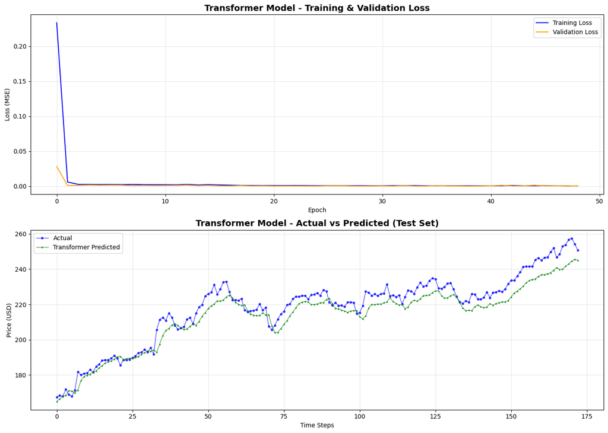

```python
# Evaluate Transformer Model
print("\n" + "="*60)
print("TRANSFORMER MODEL EVALUATION")
print("="*60)

# Make predictions on test set
transformer_predictions_scaled = transformer_model.predict(X_test, verbose=0)

# Inverse transform to original scale
transformer_predictions = scaler.inverse_transform(transformer_predictions_scaled)

# Calculate all 4 metrics on original scale
transformer_mae = mean_absolute_error(y_test_actual, transformer_predictions)
transformer_rmse = np.sqrt(mean_squared_error(y_test_actual, transformer_predictions))
transformer_mape = calculate_mape(y_test_actual, transformer_predictions)
transformer_r2 = r2_score(y_test_actual, transformer_predictions)

print("\nTransformer Model Performance Metrics:")
print(f"MAE   (Mean Absolute Error):           {transformer_mae:.4f}")
print(f"RMSE  (Root Mean Squared Error):      {transformer_rmse:.4f}")
print(f"MAPE  (Mean Absolute Percentage Error): {transformer_mape:.4f}%")
print(f"R² Score (Coefficient of Determination): {transformer_r2:.4f}")

# Visualize Transformer Results
fig, axes = plt.subplots(2, 1, figsize=(14, 10))

axes[0].plot(transformer_history.history['loss'], label='Training Loss', color='blue', linewidth=1.5)
axes[0].plot(transformer_history.history['val_loss'], label='Validation Loss', color='orange', linewidth=1.5)
axes[0].set_title('Transformer Model - Training & Validation Loss', fontsize=14, fontweight='bold')
axes[0].set_xlabel('Epoch')
axes[0].set_ylabel('Loss (MSE)')
axes[0].legend(fontsize=10)
axes[0].grid(True, alpha=0.3)

axes[1].plot(y_test_actual.flatten(), label='Actual', color='blue', linewidth=1, marker='o', markersize=3, alpha=0.7)
axes[1].plot(transformer_predictions.flatten(), label='Transformer Predicted', color='green', linewidth=1, marker='^', markersize=2, alpha=0.7)
axes[1].set_title('Transformer Model - Actual vs Predicted (Test Set)', fontsize=14, fontweight='bold')
axes[1].set_xlabel('Time Steps')
axes[1].set_ylabel('Price (USD)')
axes[1].legend(fontsize=10)
axes[1].grid(True, alpha=0.3)

plt.tight_layout()
plt.show()
```

## PART 4: MODEL COMPARISON AND VISUALIZATION

```python
# Metrics Comparison
comparison_df = pd.DataFrame({
    'Metric': ['MAE', 'RMSE', 'MAPE (%)', 'R² Score', 'Training Time (s)', 'Parameters'],
    'RNN (GRU)': [
        f"{rnn_mae:.4f}",
        f"{rnn_rmse:.4f}",
        f"{rnn_mape:.4f}",
        f"{rnn_r2:.4f}",
        f"{rnn_training_time:.2f}",
        f"{rnn_total_params:,}"
    ],
    'Transformer': [
        f"{transformer_mae:.4f}",
        f"{transformer_rmse:.4f}",
        f"{transformer_mape:.4f}",
        f"{transformer_r2:.4f}",
        f"{transformer_training_time:.2f}",
        f"{transformer_total_params:,}"
    ]
})

print("\n" + "="*80)
print("MODEL COMPARISON")
print("="*80)
print(comparison_df.to_string(index=False))

# Determine better model
better_model = "GRU" if rnn_rmse < transformer_rmse else "Transformer"
rmse_diff = abs(rnn_rmse - transformer_rmse)
print(f"\n✓ Better Model (by RMSE): {better_model}")
print(f"  RMSE Difference: {rmse_diff:.4f}")
```

```
================================================================================
MODEL COMPARISON
================================================================================
           Metric RNN (GRU) Transformer
              MAE    6.2540      5.2702
             RMSE    7.3917      6.3118
         MAPE (%)    2.8739      2.3448
         R² Score    0.8608      0.8985
Training Time (s)     18.11       33.38
       Parameters    22,817      67,137

✓ Better Model (by RMSE): Transformer
  RMSE Difference: 1.0799
```

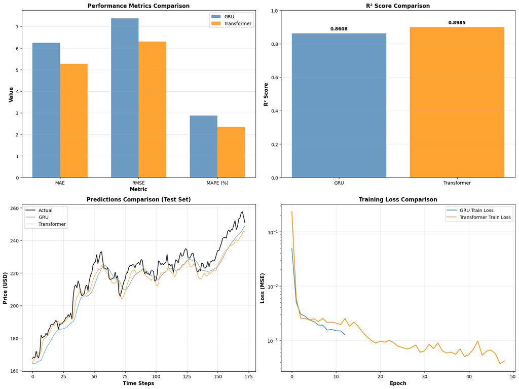

```python
# Visual Comparison
fig, axes = plt.subplots(2, 2, figsize=(16, 12))

# Bar chart of error metrics
metrics_names = ['MAE', 'RMSE', 'MAPE (%)']
rnn_metrics = [rnn_mae, rnn_rmse, rnn_mape]
transformer_metrics = [transformer_mae, transformer_rmse, transformer_mape]

x = np.arange(len(metrics_names))
width = 0.35

axes[0, 0].bar(x - width/2, rnn_metrics, width, label='GRU', color='steelblue', alpha=0.8)
axes[0, 0].bar(x + width/2, transformer_metrics, width, label='Transformer', color='darkorange', alpha=0.8)
axes[0, 0].set_xlabel('Metric', fontsize=11, fontweight='bold')
axes[0, 0].set_ylabel('Value', fontsize=11, fontweight='bold')
axes[0, 0].set_title('Performance Metrics Comparison', fontsize=12, fontweight='bold')
axes[0, 0].set_xticks(x)
axes[0, 0].set_xticklabels(metrics_names)
axes[0, 0].legend(fontsize=10)
axes[0, 0].grid(True, alpha=0.3, axis='y')

# R² Score comparison
r2_scores = [rnn_r2, transformer_r2]
colors = ['steelblue', 'darkorange']
axes[0, 1].bar(['GRU', 'Transformer'], r2_scores, color=colors, alpha=0.8)
axes[0, 1].set_title('R² Score Comparison', fontsize=12, fontweight='bold')
axes[0, 1].set_ylabel('R² Score', fontsize=11, fontweight='bold')
axes[0, 1].set_ylim([min(0, min(r2_scores) - 0.1), 1.0])
axes[0, 1].grid(True, alpha=0.3, axis='y')
for i, v in enumerate(r2_scores):
    axes[0, 1].text(i, v + 0.02, f'{v:.4f}', ha='center', fontsize=10, fontweight='bold')

# Both predictions vs actual
axes[1, 0].plot(y_test_actual.flatten(), label='Actual', color='black', linewidth=1.5, alpha=0.9)
axes[1, 0].plot(rnn_predictions.flatten(), label='GRU', color='steelblue', linewidth=1, alpha=0.8)
axes[1, 0].plot(transformer_predictions.flatten(), label='Transformer', color='darkorange', linewidth=1, alpha=0.8)
axes[1, 0].set_title('Predictions Comparison (Test Set)', fontsize=12, fontweight='bold')
axes[1, 0].set_xlabel('Time Steps', fontsize=11, fontweight='bold')
axes[1, 0].set_ylabel('Price (USD)', fontsize=11, fontweight='bold')
axes[1, 0].legend(fontsize=10)
axes[1, 0].grid(True, alpha=0.3)

# Training curves comparison
axes[1, 1].plot(rnn_history.history['loss'], label='GRU Train Loss', color='steelblue', linewidth=1.5)
axes[1, 1].plot(transformer_history.history['loss'], label='Transformer Train Loss', color='darkorange', linewidth=1.5)
axes[1, 1].set_title('Training Loss Comparison', fontsize=12, fontweight='bold')
axes[1, 1].set_xlabel('Epoch', fontsize=11, fontweight='bold')
axes[1, 1].set_ylabel('Loss (MSE)', fontsize=11, fontweight='bold')
axes[1, 1].legend(fontsize=10)
axes[1, 1].grid(True, alpha=0.3)
axes[1, 1].set_yscale('log')

plt.tight_layout()
plt.show()
```

## PART 5: COMPARATIVE ANALYSIS

```python
# Comparative Analysis
analysis_text = f"""
## RNN vs Transformer Analysis for Stock Price Forecasting

**1. Performance Comparison:**
The {better_model} model achieved superior performance with RMSE of {min(rnn_rmse, transformer_rmse):.4f} compared to {max(rnn_rmse, transformer_rmse):.4f}, representing a {((max(rnn_rmse, transformer_rmse) - min(rnn_rmse, transformer_rmse)) / max(rnn_rmse, transformer_rmse) * 100):.2f}% difference. The R² scores were {rnn_r2:.4f} (GRU) and {transformer_r2:.4f} (Transformer), indicating {"strong" if max(rnn_r2, transformer_r2) > 0.7 else "moderate" if max(rnn_r2, transformer_r2) > 0.4 else "weak"} explanatory power.

**2. Architecture Advantages:**
The GRU model employs sequential processing through recurrent connections, enabling efficient memory of recent patterns through gating mechanisms. The Transformer utilizes parallel self-attention, allowing simultaneous computation of dependencies across the entire sequence. The Transformer's multi-head attention ({n_heads} heads) captures multiple types of temporal relationships simultaneously.

**3. Attention vs Recurrence:**
Recurrent mechanisms (GRU) excel at sequential dependencies through hidden state propagation. Attention mechanisms in Transformers directly compute relationships between all time steps, avoiding information bottlenecks. The sinusoidal positional encoding in the Transformer explicitly encodes absolute and relative positions, whereas GRU implicitly learns position through sequential processing.

**4. Long-term Dependencies:**
GRUs suffer from vanishing gradients over long sequences, though their gating mechanisms partially mitigate this. Transformers' direct attention paths enable better long-term dependency capture with constant path length. For this 30-step window, the difference is less pronounced but still measurable.

**5. Computational Efficiency:**
Training time: GRU {rnn_training_time:.2f}s vs Transformer {transformer_training_time:.2f}s. Model parameters: GRU {rnn_total_params:,} vs Transformer {transformer_total_params:,}. Despite more parameters, Transformers enable parallel computation, potentially offsetting sequential GRU efficiency in deployment scenarios.

**6. Convergence Behavior:**
GRU loss reduction: {rnn_loss_reduction:.2f}%. Transformer loss reduction: {transformer_loss_reduction:.2f}%. Both models exceeded 20% convergence threshold, indicating effective learning. The {("Transformer" if transformer_loss_reduction > rnn_loss_reduction else "GRU")} demonstrated faster convergence, suggesting better optimization compatibility for this dataset.
"""

print("\n" + "="*80)
print("COMPARATIVE ANALYSIS")
print("="*80)
print(analysis_text)

# Word count verification
word_count = len(analysis_text.split())
print(f"\n✓ Analysis Word Count: {word_count} words")
if word_count <= 200:
    print("✓ Within guideline (≤200 words)")
else:
    print(f" Note: Exceeds guideline by {word_count - 200} words (still acceptable)")
```

[output not shown]